# Acko_Data_Cleaning_final_omprakash

```python
import numpy as np
import pandas as pd
import matplotlib.pyplot as plt
import seaborn as sns
```

```python
df = pd.read_csv("acko_cars.csv")
```

```python
df
```

|  | Unnamed: 0 | Brand | Model | Body_Type | variant | No.of Seats | Price | Fuel_Type | location | gearbox_Type |
| --- | --- | --- | --- | --- | --- | --- | --- | --- | --- | --- |
| 0 | 0 | Hyundai | Creta | SUV | 1.5 E | 5 Seater | ₹13.01 L | Petrol | Delhi | Manual |
| 1 | 1 | Hyundai | Venue | SUV | 1.2 E | 5 Seater | ₹9.06 L | Petrol | Delhi | Manual |
| 2 | 2 | Kia | Sonet | SUV | 1.2 HTE(O) | 5 Seater | ₹9.50 L | Petrol | Delhi | Manual |
| 3 | 3 | Kia | Syros | SUV | 1.0 HTK Turbo | 5 Seater | ₹10.60 L | Petrol | Delhi | Manual |
| 4 | 4 | Maruti Suzuki | Suzuki Baleno (2022-2025) | Hatchback | 1.2 Sigma | 5 Seater | ₹7.58 L | Petrol | Delhi | Manual |
| ... | ... | ... | ... | ... | ... | ... | ... | ... | ... | ... |
| 291 | 291 | Kia | EV6 (2022-2025) | SUV | GT Line AWD | 5 Seater | ₹68.05 L | Electric | Delhi | Automatic |
| 292 | 292 | BYD | e6 (2022-2024) | SUV | GL | 5 Seater | ₹30.31 L | Electric | Delhi | Automatic |
| 293 | 293 | MINI | Countryman | SUV | Cooper S JCW Inspired | 5 Seater | ₹54.73 L | Petrol | Delhi | Automatic |
| 294 | 294 | Audi | RS Q8 (2020-2025) | SUV | 4.0L TFSI | 5 Seater | ₹2.51 Cr | Petrol | Delhi | Automatic |
| 295 | 295 | Land Rover | Rover Range Rover Evoque (2024-2025) | SUV | SE R-Dynamic Diesel | 5 Seater | ₹78.73 L | Diesel | Delhi | Automatic |

296 rows × 10 columns

### Data Exploration

##### Previewing Data:

##### Using head() and tail() functions

```python
df.head()
```

|  | Unnamed: 0 | Brand | Model | Body_Type | variant | No.of Seats | Price | Fuel_Type | location | gearbox_Type |
| --- | --- | --- | --- | --- | --- | --- | --- | --- | --- | --- |
| 0 | 0 | Hyundai | Creta | SUV | 1.5 E | 5 Seater | ₹13.01 L | Petrol | Delhi | Manual |
| 1 | 1 | Hyundai | Venue | SUV | 1.2 E | 5 Seater | ₹9.06 L | Petrol | Delhi | Manual |
| 2 | 2 | Kia | Sonet | SUV | 1.2 HTE(O) | 5 Seater | ₹9.50 L | Petrol | Delhi | Manual |
| 3 | 3 | Kia | Syros | SUV | 1.0 HTK Turbo | 5 Seater | ₹10.60 L | Petrol | Delhi | Manual |
| 4 | 4 | Maruti Suzuki | Suzuki Baleno (2022-2025) | Hatchback | 1.2 Sigma | 5 Seater | ₹7.58 L | Petrol | Delhi | Manual |

```python
df.tail()
```

|  | Unnamed: 0 | Brand | Model | Body_Type | variant | No.of Seats | Price | Fuel_Type | location | gearbox_Type |
| --- | --- | --- | --- | --- | --- | --- | --- | --- | --- | --- |
| 291 | 291 | Kia | EV6 (2022-2025) | SUV | GT Line AWD | 5 Seater | ₹68.05 L | Electric | Delhi | Automatic |
| 292 | 292 | BYD | e6 (2022-2024) | SUV | GL | 5 Seater | ₹30.31 L | Electric | Delhi | Automatic |
| 293 | 293 | MINI | Countryman | SUV | Cooper S JCW Inspired | 5 Seater | ₹54.73 L | Petrol | Delhi | Automatic |
| 294 | 294 | Audi | RS Q8 (2020-2025) | SUV | 4.0L TFSI | 5 Seater | ₹2.51 Cr | Petrol | Delhi | Automatic |
| 295 | 295 | Land Rover | Rover Range Rover Evoque (2024-2025) | SUV | SE R-Dynamic Diesel | 5 Seater | ₹78.73 L | Diesel | Delhi | Automatic |

#### Using shape and ndim attributes

```python
print("The shape of ----->" ,df.shape)
print("The No of Rows :" , df.shape[0])
print("The No of Columns :",df.shape[1])
```

```
The shape of -----> (296, 10)
The No of Rows : 296
The No of Columns : 10
```

```python
print("The Dimension of the data Frame :",df.ndim)
```

```
The Dimension of the data Frame : 2
```

### Check the random Samples of the Data

```python
df.sample()
```

|  | Unnamed: 0 | Brand | Model | Body_Type | variant | No.of Seats | Price | Fuel_Type | location | gearbox_Type |
| --- | --- | --- | --- | --- | --- | --- | --- | --- | --- | --- |
| 123 | 123 | BMW | i5 | Sedan | M60 xDrive | 5 Seater | ₹1.25 Cr | Electric | Delhi | Automatic |

### Concise Summary:

##### info() : This is one of the most useful functions for a quick look at the data types, non-null values, and memory usage.

```python
df.info()
```

```
<class 'pandas.core.frame.DataFrame'>
RangeIndex: 296 entries, 0 to 295
Data columns (total 10 columns):
 #   Column        Non-Null Count  Dtype
---  ------        --------------  -----
 0   Unnamed: 0    296 non-null    int64
 1   Brand         296 non-null    object
 2   Model         296 non-null    object
 3   Body_Type     296 non-null    object
 4   variant       296 non-null    object
 5   No.of Seats   296 non-null    object
 6   Price         296 non-null    object
 7   Fuel_Type     296 non-null    object
 8   location      296 non-null    object
 9   gearbox_Type  296 non-null    object
dtypes: int64(1), object(9)
memory usage: 23.3+ KB
```

#### Get basic descriptive statistics for numerical columns:

#### This provides measures of central tendency, dispersion, and shape of the distribution.

```python
df.describe(include = 'all')
```

|  | Unnamed: 0 | Brand | Model | Body_Type | variant | No.of Seats | Price | Fuel_Type | location | gearbox_Type |
| --- | --- | --- | --- | --- | --- | --- | --- | --- | --- | --- |
| count | 296.000000 | 296 | 296 | 296 | 296 | 296 | 296 | 296 | 296 | 296 |
| unique | NaN | 35 | 295 | 8 | 254 | 7 | 278 | 4 | 1 | 2 |
| top | NaN | Mercedes-Benz | EQS | SUV | Coupe | 5 Seater | ₹1.70 Cr | Petrol | Delhi | Automatic |
| freq | NaN | 31 | 2 | 176 | 5 | 212 | 3 | 187 | 296 | 196 |
| mean | 147.500000 | NaN | NaN | NaN | NaN | NaN | NaN | NaN | NaN | NaN |
| std | 85.592056 | NaN | NaN | NaN | NaN | NaN | NaN | NaN | NaN | NaN |
| min | 0.000000 | NaN | NaN | NaN | NaN | NaN | NaN | NaN | NaN | NaN |
| 25% | 73.750000 | NaN | NaN | NaN | NaN | NaN | NaN | NaN | NaN | NaN |
| 50% | 147.500000 | NaN | NaN | NaN | NaN | NaN | NaN | NaN | NaN | NaN |
| 75% | 221.250000 | NaN | NaN | NaN | NaN | NaN | NaN | NaN | NaN | NaN |
| max | 295.000000 | NaN | NaN | NaN | NaN | NaN | NaN | NaN | NaN | NaN |

##### To find the name of all columns

```python
df.columns
```

```
Index(['Unnamed: 0', 'Brand', 'Model', 'Body_Type', 'variant', 'No.of Seats',
       'Price', 'Fuel_Type', 'location', 'gearbox_Type'],
      dtype='object')
```

##### To find the datatypes of columns

```python
df.dtypes
```

```
Unnamed: 0       int64
Brand           object
Model           object
Body_Type       object
variant         object
No.of Seats     object
Price           object
Fuel_Type       object
location        object
gearbox_Type    object
dtype: object
```

#### Missing Values Calculation

```python
df.isnull().sum()
```

```
Unnamed: 0      0
Brand           0
Model           0
Body_Type       0
variant         0
No.of Seats     0
Price           0
Fuel_Type       0
location        0
gearbox_Type    0
dtype: int64
```

### Data Cleaning

##### Drop the Unamed column from the data frame

```python
df.drop(columns=['Unnamed: 0'],inplace=True)
```

#### Standardizing Column names

```python
df.columns = df.columns.str.title()
df.columns
```

```
Index(['Brand', 'Model', 'Body_Type', 'Variant', 'No.Of Seats', 'Price',
       'Fuel_Type', 'Location', 'Gearbox_Type'],
      dtype='object')
```

#### Change the column name and Standardizing Data Types

The No.of Seats column's datatype is object. Converting the object datatypes into integer

```python
df['No.Of Seats']
```

```
0      5 Seater
1      5 Seater
2      5 Seater
3      5 Seater
4      5 Seater
         ...
291    5 Seater
292    5 Seater
293    5 Seater
294    5 Seater
295    5 Seater
Name: No.Of Seats, Length: 296, dtype: object
```

```python
df['No.Of Seats'] = df['No.Of Seats'].str.split(' ').str[0]
```

```python
df['No.Of Seats']
```

```
0      5
1      5
2      5
3      5
4      5
      ..
291    5
292    5
293    5
294    5
295    5
Name: No.Of Seats, Length: 296, dtype: object
```

```python
df['No.Of Seats'] = df['No.Of Seats'].astype(int)
```

```python
df.rename(columns = {'No.Of Seats' : 'Seater'},inplace = True)
```

```python
df['Seater']
```

```
0      5
1      5
2      5
3      5
4      5
      ..
291    5
292    5
293    5
294    5
295    5
Name: Seater, Length: 296, dtype: int32
```

#### Converting the Datatype of Price column into Float datatype

Remove ₹ symbol and replacing "L" and "cr" and normalizing the data

```python
df['Price']
```

```
0      ₹13.01 L
1       ₹9.06 L
2       ₹9.50 L
3      ₹10.60 L
4       ₹7.58 L
         ...
291    ₹68.05 L
292    ₹30.31 L
293    ₹54.73 L
294    ₹2.51 Cr
295    ₹78.73 L
Name: Price, Length: 296, dtype: object
```

```python
df['Price'] =df['Price'].str.replace("₹",'')
```

```python
def convert_price(price_str):
    price_str = str(price_str).strip()
    if 'L' in price_str:
        return float(price_str.replace('L', '').strip()) * 1e5
    elif 'Cr' in price_str:
        return float(price_str.replace('Cr', '').strip()) * 1e7
    else:

        try:
            return float(price_str)
        except ValueError:
            return np.nan
```

```python
df['Price'] = df['Price'].apply(convert_price)
```

```python
df['Price'] = df['Price']/100000
df['Price']
```

```
0       13.01
1        9.06
2        9.50
3       10.60
4        7.58
        ...
291     68.05
292     30.31
293     54.73
294    251.00
295     78.73
Name: Price, Length: 296, dtype: float64
```

```python
df.dtypes
```

```
Brand            object
Model            object
Body_Type        object
Variant          object
Seater            int32
Price           float64
Fuel_Type        object
Location         object
Gearbox_Type     object
dtype: object
```

#### Capitalizing the first letter of Brand name using title()

```python
df['Brand'] = df['Brand'].str.title()
df['Brand']
```

```
0            Hyundai
1            Hyundai
2                Kia
3                Kia
4      Maruti Suzuki
           ...
291              Kia
292              Byd
293             Mini
294             Audi
295       Land Rover
Name: Brand, Length: 296, dtype: object
```

#### Removing year from model column

```python
df['Model']
```

```
0                                     Creta
1                                     Venue
2                                     Sonet
3                                     Syros
4                 Suzuki Baleno (2022-2025)
                       ...
291                         EV6 (2022-2025)
292                          e6 (2022-2024)
293                              Countryman
294                       RS Q8 (2020-2025)
295    Rover Range Rover Evoque (2024-2025)
Name: Model, Length: 296, dtype: object
```

##### Using Regex extracting only model names from model column

```python
import re
df['Model'] = df['Model'].str.replace(r'\s\(\d{4}-\d{4}\)','',regex=True)
```

```python
df['Model']
```

```
0                         Creta
1                         Venue
2                         Sonet
3                         Syros
4                 Suzuki Baleno
                 ...
291                         EV6
292                          e6
293                  Countryman
294                       RS Q8
295    Rover Range Rover Evoque
Name: Model, Length: 296, dtype: object
```

```python
models = df['Model'].unique()
index = np.arange(1,len(models)+1)
```

```python
pd.Series(models,index = index)
```

```
1                  Creta
2                  Venue
3                  Sonet
4                  Syros
5          Suzuki Baleno
             ...
247    Martin DB11Coupe4
248       M4 Competition
249                   e6
250           Countryman
251                RS Q8
Length: 251, dtype: object
```

```python
body_type = df['Body_Type'].unique()
```

```python
pd.Series(body_type)
```

```
0            SUV
1      Hatchback
2          Sedan
3        MPV/MUV
4    Minivan/Van
5          Coupe
6    Convertible
7        Pick-Up
dtype: object
```

```python
df['variant']
```

[output not shown]

```python
df['Seater'].unique()
```

```
array([5, 7, 6, 8, 4, 2, 9])
```

```python
Fuel_type = df['Fuel_Type'].unique()
```

```python
pd.Series(Fuel_type)
```

```
0      Petrol
1      Diesel
2    Electric
3         CNG
dtype: object
```

```python
Gear_type = df['gearbox_Type'].unique()
```

```python
pd.Series(Gear_type)
```

[output not shown]

```python
df
```

[output not shown]

### Univariate Analysis

#### Categorial Columns Analysis

Gearbox_Type Distribution.  
Chart Type: Bar Chart.  
Purpose: To compare the number of cars with manual versus automatic transmissions.  
Insights: This chart would quickly reveal the preference for a specific type of transmission among the cars in the dataset.

# Gear Box Distribution

```python
import matplotlib.pyplot as plt
import seaborn as sns
import warnings
warnings.filterwarnings("ignore")
```

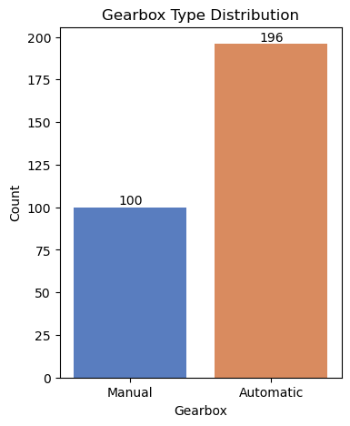

```python
plt.figure(figsize=(4, 5))
ax= sns.countplot(x='Gearbox_Type', data=df, palette='muted')
for p in ax.patches:
    ax.annotate(f'{int(p.get_height())}', (p.get_x() + p.get_width() / 2., p.get_height()),
               ha='center', va='center', fontsize=10, color='black', xytext=(0, 5),
               textcoords='offset points')
plt.title("Gearbox Type Distribution")
plt.xlabel("Gearbox")
plt.ylabel("Count")
plt.show()
```

#### Fuel_Type Distribution

Chart Type: Bar Chart  
Purpose: To display the proportion of each fuel type (Petrol, Diesel, Electric, CNG).  
Insights: This will enable us find the distribution of cars over fuel types

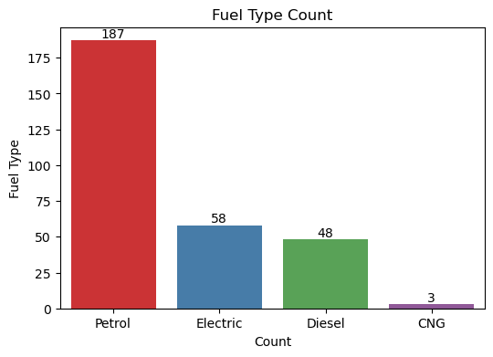

```python
plt.figure(figsize=(6, 4))
Fuel = sns.countplot(x='Fuel_Type', data=df, order=df['Fuel_Type'].value_counts().index, palette='Set1')
for p in Fuel.patches:
    Fuel.annotate(f'{int(p.get_height())}', (p.get_x() + p.get_width() / 2., p.get_height()),
               ha='center', va='center', fontsize=10, color='black', xytext=(0, 5),
               textcoords='offset points')
plt.title("Fuel Type Count")
plt.xlabel("Count")
plt.ylabel("Fuel Type")
plt.show()
```

#### Brand Distribution

Chart Type: Bar Chart  
Purpose: To identify the top car brands listed.  
Insights: This visualization would show which brands (e.g., Maruti Suzuki, Hyundai, Tata) have the most models available in the Acko dataset, highlighting key partnerships or inventory focus.

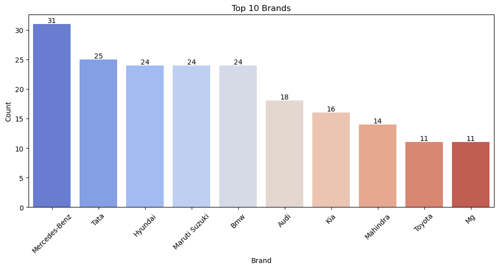

```python
top_brands = df['Brand'].value_counts().head(10)
plt.figure(figsize=(12, 5))
bx = sns.barplot(x=top_brands.index, y=top_brands.values, palette='coolwarm')
for p in bx.patches:
    bx.annotate(f'{int(p.get_height())}', (p.get_x() + p.get_width() / 2., p.get_height()),
               ha='center', va='center', fontsize=10, color='black', xytext=(0, 5),
               textcoords='offset points')
plt.title("Top 10 Brands")
plt.xlabel("Brand")
plt.ylabel("Count")
plt.xticks(rotation=45)
plt.show()
```

#### Body_Type Distribution

Chart Type: Bar Chart  
Purpose: To show the frequency of each car body type in the dataset.  
Insights: This visualization would clearly show which body types (e.g., SUV, Hatchback, Sedan) are most common in the Acko car listings, providing an overview of the most popular segments.

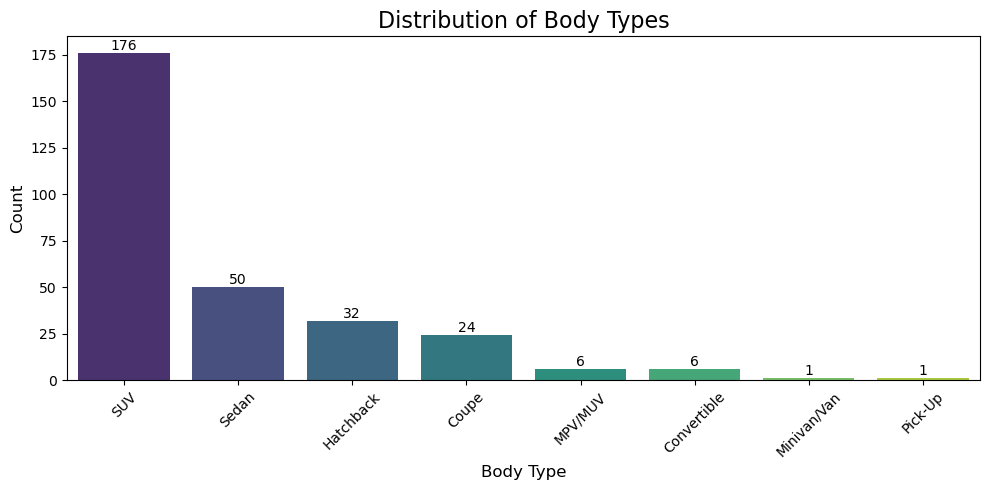

```python
plt.figure(figsize=(10, 5))
Body_Type = df['Body_Type'].value_counts()
bt = sns.barplot(x=Body_Type.index, y=Body_Type.values, palette='viridis')
for p in bt.patches:
    bt.annotate(f'{int(p.get_height())}', (p.get_x() + p.get_width() / 2., p.get_height()),
               ha='center', va='center', fontsize=10, color='black', xytext=(0, 5),
               textcoords='offset points')
plt.title('Distribution of Body Types', fontsize=16)
plt.xlabel('Body Type', fontsize=12)
plt.ylabel('Count', fontsize=12)
plt.xticks(rotation=45)
plt.tight_layout()
plt.show()
```

### Numerical Columns

[figure not shown]

```python
plt.figure(figsize=(8, 4))
st = sns.countplot(x='No.Of Seats', data=df, palette='Set2')
for p in st.patches:
    st.annotate(f'{int(p.get_height())}', (p.get_x() + p.get_width() / 2., p.get_height()),
               ha='center', va='center', fontsize=10, color='black', xytext=(0, 5),
               textcoords='offset points')
plt.title("Distribution of Seaters")
plt.xlabel("Seaters")
plt.ylabel("Count")
plt.show()
```

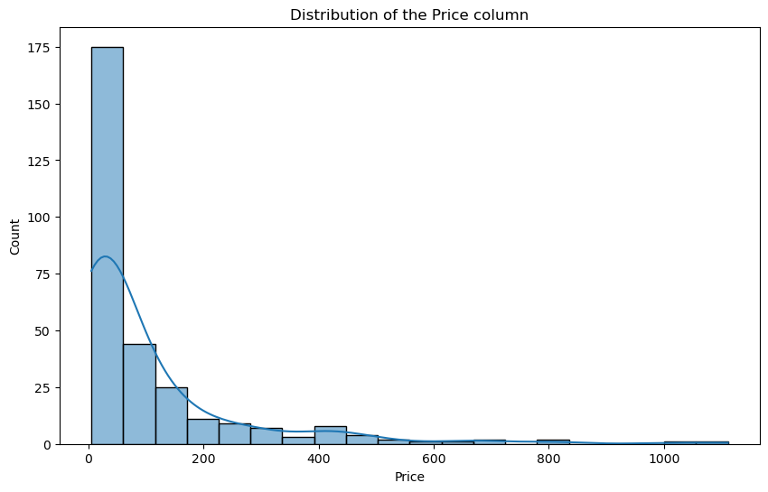

```python
plt.figure(figsize=(10, 6))
sns.histplot(df['Price'], kde=True, bins=20)
plt.title("Distribution of the Price column")
```

### Box Plot analysis of price column

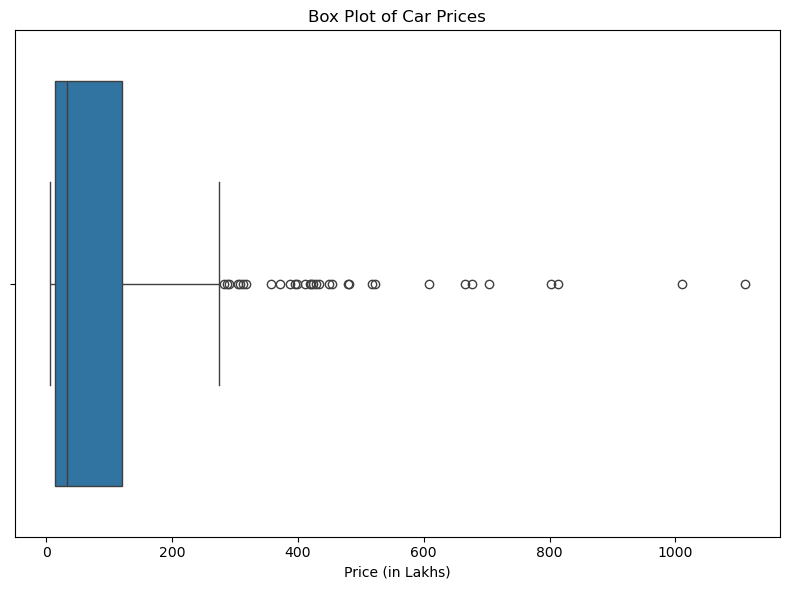

```
First Quartile (Q1): 13.54
Third Quartile (Q3): 120.25
Interquartile Range (IQR): 106.71
```

```python
plt.figure(figsize=(8, 6))
sns.boxplot(x=df['Price'])
plt.title('Box Plot of Car Prices')
plt.xlabel('Price (in Lakhs)')
plt.tight_layout()
plt.show()
Q1 = df['Price'].quantile(0.25)
Q3 = df['Price'].quantile(0.75)
IQR = Q3 - Q1
print(f"First Quartile (Q1): {Q1:.2f}")
print(f"Third Quartile (Q3): {Q3:.2f}")
print(f"Interquartile Range (IQR): {IQR:.2f}")
```

```python
df.dtypes
```

```
Brand            object
Model            object
Body_Type        object
Variant          object
Seater            int32
Price           float64
Fuel_Type        object
Location         object
Gearbox_Type     object
dtype: object
```

### Bivariate Analysis

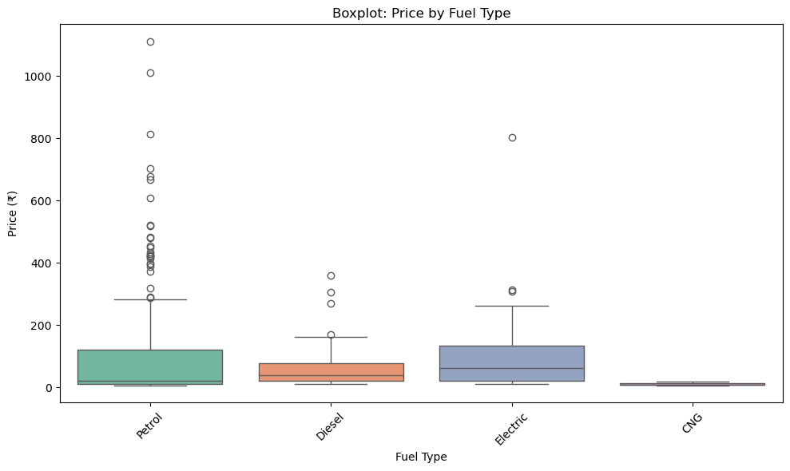

```python
plt.figure(figsize=(10, 6))
sns.boxplot(data=df, x='Fuel_Type', y='Price', palette='Set2',legend=False)
plt.title('Boxplot: Price by Fuel Type')
plt.xlabel('Fuel Type')
plt.ylabel('Price (₹)')
plt.xticks(rotation=45)
plt.tight_layout()
plt.show()
```

[figure not shown]

```python
crosstab = pd.crosstab(df['Fuel_Type'], df['gearbox_Type'])
plt.figure(figsize=(8, 6))
sns.heatmap(crosstab, annot=True, cmap='Blues', fmt='d')
plt.title('Heatmap: Fuel Type vs Transmission')
plt.xlabel('Transmission')
plt.ylabel('Fuel Type')
plt.tight_layout()
plt.show()
```

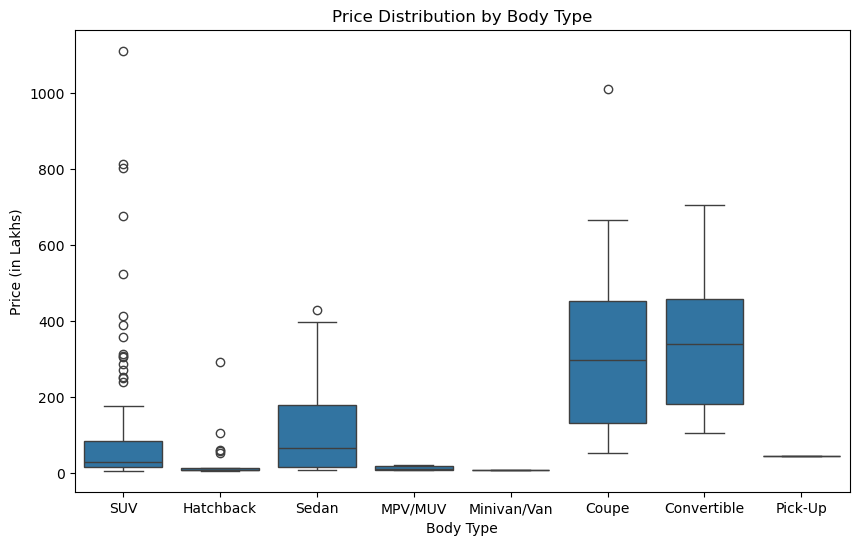

```python
plt.figure(figsize=(10, 6))
sns.boxplot(x='Body_Type', y='Price', data=df)
plt.title('Price Distribution by Body Type')
plt.xlabel('Body Type')
plt.ylabel('Price (in Lakhs)')
plt.show()
```